# rjd3highfreq

rjd3highfreq provides functions for seasonal adjustment of high-frequency data displaying multiple, non integer periodicities. Pre-adjustment with extended airline model and Arima Model Based decomposition.

## Installation

Running rjd3 packages requires **Java 17 or higher**. How to set up such a configuration in R is explained [here](https://jdemetra-new-documentation.netlify.app/#Rconfig)

You can install the development version of **rjd3highfreq** from [GitHub](https://github.com/) with:

```r
# Install development version from GitHub
# install.packages("remotes")
remotes::install_github("rjdverse/rjd3highfreq")
```

## Demonstration with the daily french births

```r
library("rjd3highfreq")
```

```r
## Import of data
df_daily <- read.csv2("https://raw.githubusercontent.com/TanguyBarthelemy/Tsace_RJD_Webinar_Dec22/b5fcf6b14ae47393554950547ef4788a0068a0f6/Data/TS_daily_births_franceM_1968_2020.csv")

# Creation of log variables to multiplicative model
df_daily$log_births <- log(df_daily$births)
df_daily$date <- as.Date(df_daily$date)
```

Plot of the raw series:

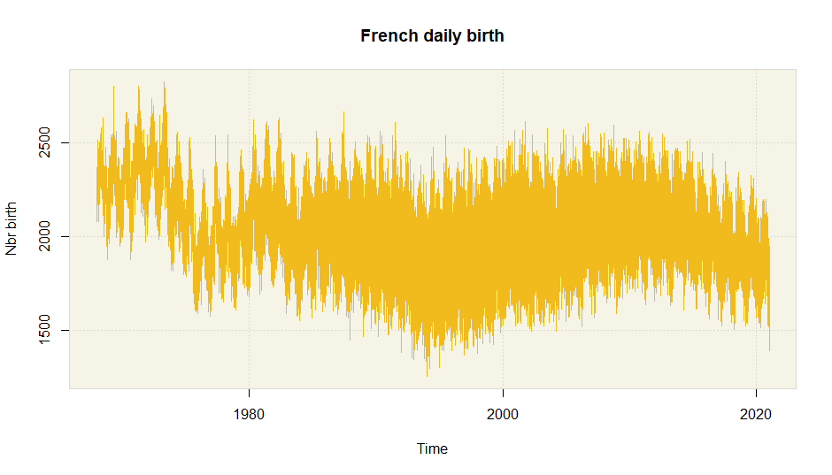

Preparation of the calendar with the package **rjd3toolkit**:

```r
# French calendar
frenchCalendar <- rjd3toolkit::national_calendar(days = list(
  rjd3toolkit::fixed_day(7, 14), # Bastille Day
  rjd3toolkit::fixed_day(5, 8, validity = list(start = "1982-05-08")), # End of 2nd WW
  rjd3toolkit::special_day('NEWYEAR'),
  rjd3toolkit::special_day('MAYDAY'), # 1st may
  rjd3toolkit::special_day('EASTERMONDAY'),
  rjd3toolkit::special_day('ASCENSION'),
  rjd3toolkit::special_day('WHITMONDAY'),
  rjd3toolkit::special_day('ASSUMPTION'),
  rjd3toolkit::special_day('ALLSAINTSDAY'), # Toussaint
  rjd3toolkit::special_day('ARMISTICE'), # End of 1st WW
  rjd3toolkit::special_day('CHRISTMAS'))
)
```

Creation of the calendar regressor in a matrix with the package **rjd3toolkit**:

```r
# Calendar regressor matrix
cal_reg <- rjd3toolkit::holidays(
    calendar = frenchCalendar,
    start = "1968-01-01", length = nrow(df_daily),
    type = "All", nonworking = 7L)

colnames(cal_reg) <- c("14th_july", "8th_may", "1st_jan", "1st_may",
                       "east_mon", "asc", "pen_mon",
                       "15th_aug", "1st_nov", "11th_nov", "Xmas")
```

Preprocessing with the function `fractionalAirlineEstimation`:

```r
pre_pro <- fractionalAirlineEstimation(
    y = df_daily$births,
    x = cal_reg,
    periods = 7, # weekly frequency
    outliers = c("ao", "wo"), log = TRUE, y_time = df_daily$date)

print(pre_pro)
```

```
#> Number of observations: 19359
#> Start: 1968-01-01
#> End: 2020-12-31
#>
#> Estimate MA parameters:
#>       MA_parameter      Coef     Coef_SE    Tstat
#>           Theta(1) 0.7620698 0.005571472 136.7807
#>  Theta(period = 7) 0.9731793 0.001413477 688.5002
#>
#> Number of calendar regressors: 11 , Number of outliers : 7
#>
#> TD regressors coefficients:
#>   Variable    Coef Coef_SE    Tstat
#>  14th_july -0.1226  0.0047 -26.0615
#>    8th_may -0.1419  0.0054 -26.3419
#>    1st_jan -0.2223  0.0047 -47.3511
#>    1st_may -0.1225  0.0047 -26.2643
#>   east_mon -0.1891  0.0046 -40.7635
#>        asc -0.1726  0.0046 -37.1949
#>    pen_mon -0.1900  0.0046 -40.9429
#>   15th_aug -0.1181  0.0047 -25.3461
#>    1st_nov -0.1503  0.0046 -32.5662
#>   11th_nov -0.1238  0.0046 -26.8142
#>       Xmas -0.2310  0.0046 -49.7435
#>
#> Outliers coefficients:
#>       Variable    Coef Coef_SE   Tstat
#>  WO.1999-12-31 -0.1762  0.0226 -7.7916
#>  AO.1995-08-15 -0.2224  0.0340 -6.5503
#>  WO.1999-12-24 -0.1447  0.0226 -6.3981
#>  AO.2012-01-01  0.2098  0.0340  6.1786
#>  AO.1998-07-14 -0.2101  0.0340 -6.1880
#>  AO.1997-07-14 -0.2092  0.0340 -6.1602
#>  AO.1995-05-01 -0.2042  0.0340 -6.0146
#>
#> Sum of square residuals: 25.17 on 19330 degrees of freedom
#> Log likelihood = 3.682e+04,
#>  aic = -7.361e+04,
#>  aicc = -7.361e+04,
#>  bic(corrected for length) = -6.635
#> Hannan–Quinn information criterion = -7.355e+04
```

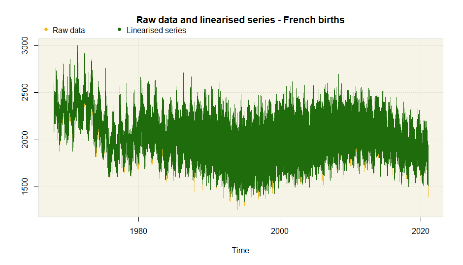

```r
plot(pre_pro, main = "French births")
```

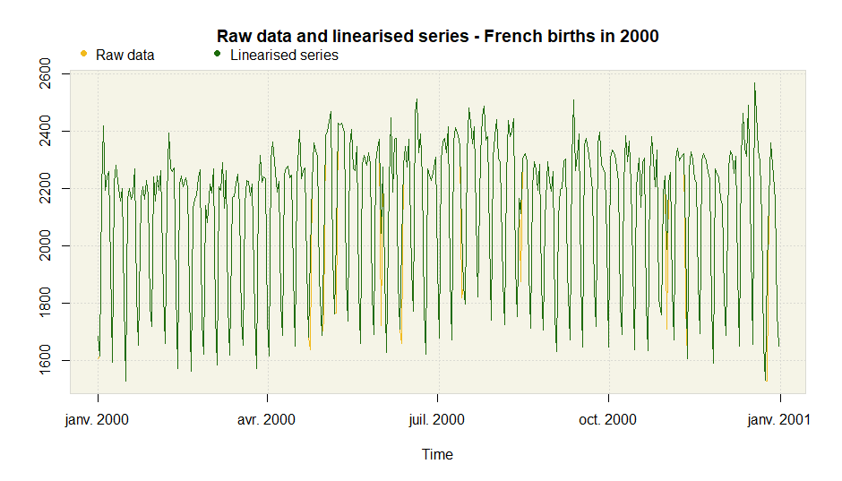

```r
plot(x = pre_pro,
     from = as.Date("2000-01-01"), to = as.Date("2000-12-31"),
     main = "French births in 2000")
```

Decomposition with the AMB (Arima Model Based) algorithm:

```r
# Decomposition with weekly pattern
amb.dow <- rjd3highfreq::fractionalAirlineDecomposition(
    y = pre_pro$model$linearized, # linearized series from preprocessing
    period = 7,
    log = TRUE, y_time = df_daily$date)

# Extract day-of-year pattern from day-of-week-adjusted linearised data
amb.doy <- rjd3highfreq::fractionalAirlineDecomposition(
    y = amb.dow$decomposition$sa, # DOW-adjusted linearised data
    period = 365.2425, # day of year pattern
    log = TRUE, y_time = df_daily$date)
```

Plot:

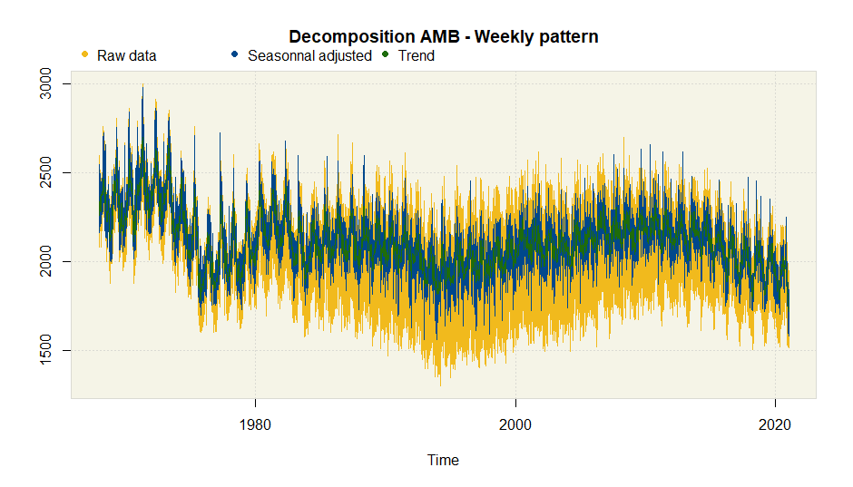

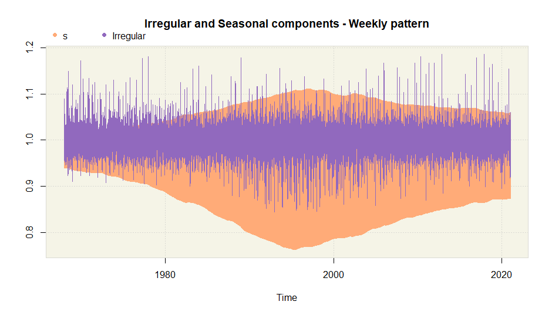

```r
plot(amb.dow, main = "Weekly pattern")
```

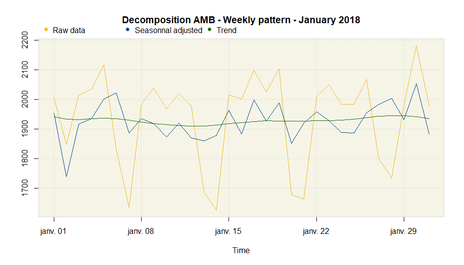

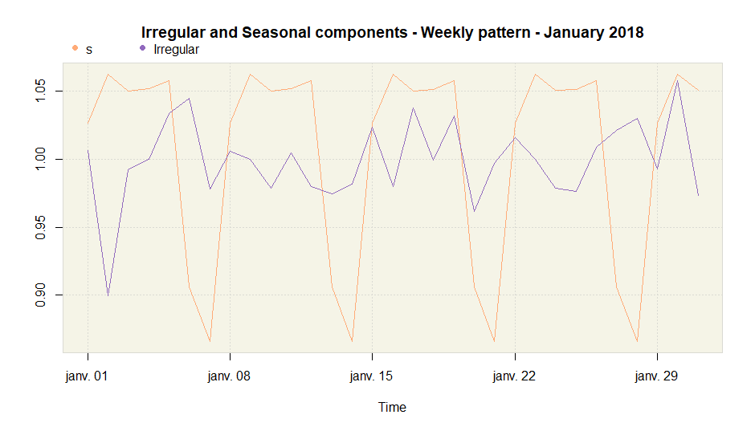

```r
plot(amb.dow, main = "Weekly pattern - January 2018",
     from = as.Date("2018-01-01"),
     to = as.Date("2018-01-31"))
```

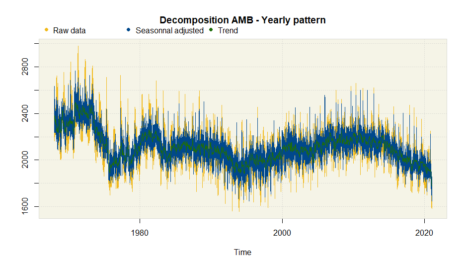

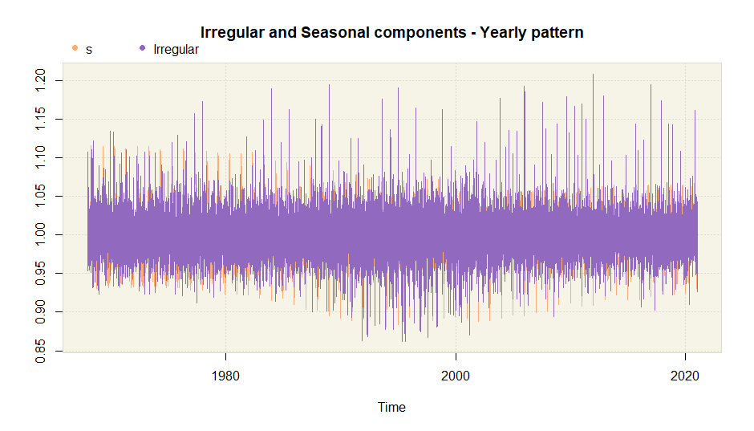

```r
plot(amb.doy, main = "Yearly pattern")
```

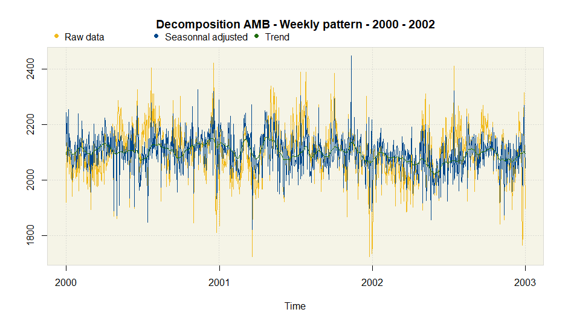

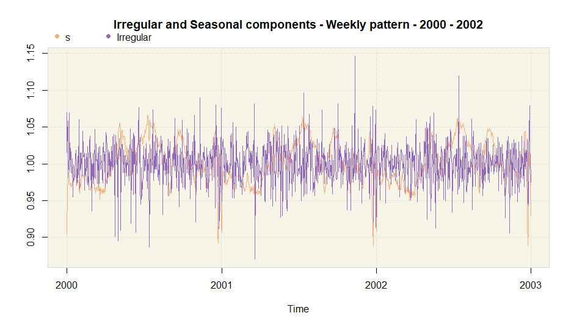

```r
plot(amb.doy, main = "Weekly pattern - 2000 - 2002",
     from = as.Date("2000-01-01"),
     to = as.Date("2002-12-31"))
```

Perform an Arima Model Based (AMB) decomposition on several periodcities at once:

```r
amb.multi <- rjd3highfreq::multiAirlineDecomposition(
  y = pre_pro$model$linearized, # input time series
  periods = c(7, 365.2425), # 2 frequency
  log = TRUE, y_time = df_daily$date)
```

Plot the comparison between the two AMB methods for the annual periodicity:

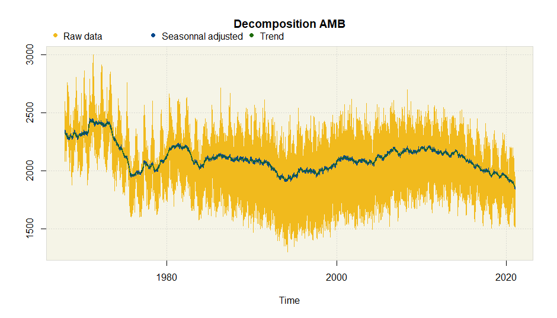

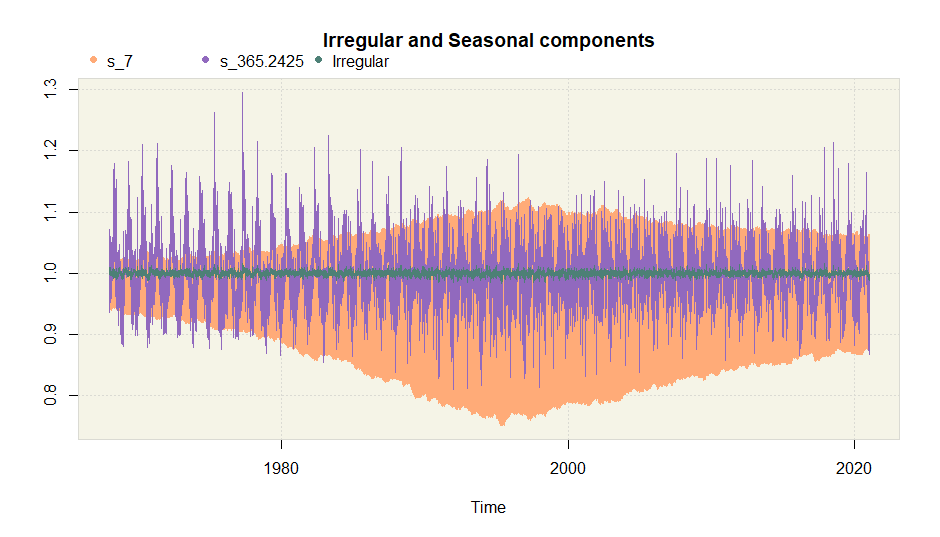

```r
plot(amb.multi)
```

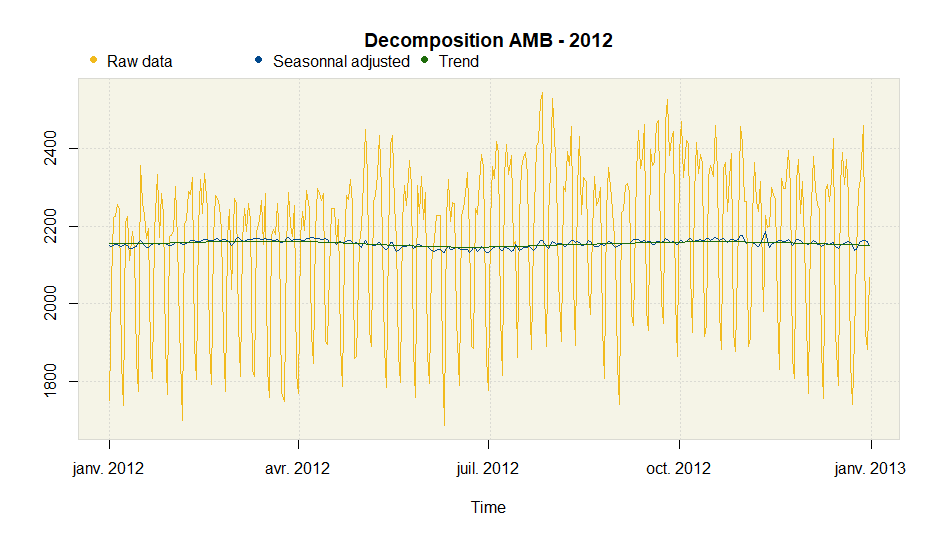

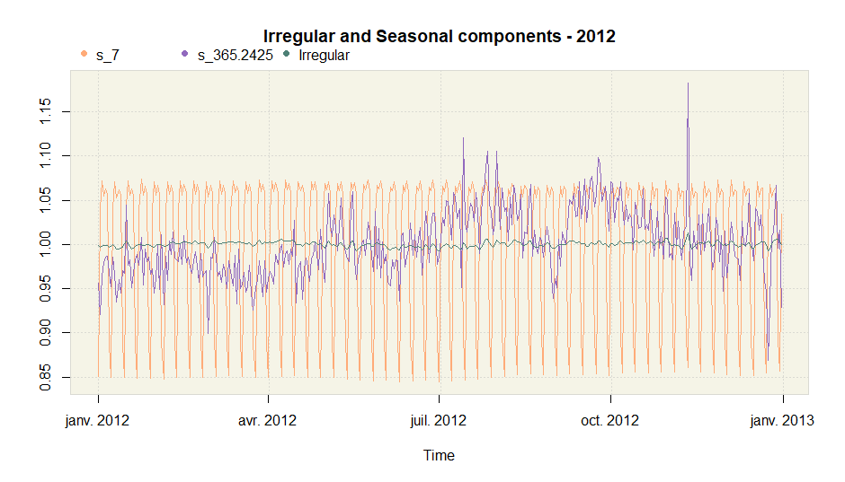

```r
plot(amb.multi, main = "2012",
     from = as.Date("2012-01-01"),
     to = as.Date("2012-12-31"))
```

With the package [**rjd3x11plus**](https://github.com/rjdverse/rjd3x11plus), you can perform an X-11 like decomposition with any (non integer) periodicity.

## Package Maintenance and contributing

Any contribution is welcome and should be done through pull requests and/or issues. pull requests should include **updated tests** and **updated documentation**. If functionality is changed, docstrings should be added or updated.

## Licensing

The code of this project is licensed under the [European Union Public Licence (EUPL)](https://joinup.ec.europa.eu/collection/eupl/eupl-text-eupl-12).